# Basketaball Stats

```python
import pandas as pd
import matplotlib.pyplot as plt #import libraries

col_df = pd.read_csv("/Users/Matthew/Desktop/Matt's Backup/Python/College_DF") # read in college stats as dataframe
nba_df = pd.read_csv("/Users/Matthew/Desktop/Matt's Backup/Python/NBA_DF") # read in NBA stats as dataframe
col_df = col_df.rename(index = str, columns = {'Unnamed: 0':'Name'}) # fix column name 1
nba_df = nba_df.rename(index = str, columns = {'Unnamed: 0':'Name'}) # fix coulmn 1 name

print(nba_df.shape)
print(col_df.shape) # check to see if number of players is same for both data frames
```

```
(400, 28)
(400, 26)
```

## Preview College Dataframe

```python
col_df.isnull().values.any() # check for any missing values
col_df.head(n=10) #preview data
```

|  | Name | G | GS | MP | FG | FGA | FG% | 2P | 2PA | 2P% | ... | ORB | DRB | TRB | AST | STL | BLK | TOV | PF | PTS | SOS |
| --- | --- | --- | --- | --- | --- | --- | --- | --- | --- | --- | --- | --- | --- | --- | --- | --- | --- | --- | --- | --- | --- |
| 0 | Karl-Anthony Towns | 39.0 | 39.0 | 21.1 | 3.7 | 6.6 | 0.566 | 3.7 | 6.4 | 0.577 | ... | 2.4 | 4.3 | 6.7 | 1.1 | 0.5 | 2.3 | 1.4 | 2.9 | 10.3 | 8.67 |
| 1 | D'Angelo Russell | 35.0 | 34.0 | 33.9 | 6.6 | 14.7 | 0.449 | 3.9 | 8.1 | 0.479 | ... | 1.0 | 4.7 | 5.7 | 5.0 | 1.6 | 0.3 | 2.9 | 2.1 | 19.3 | 7.37 |
| 2 | Jahlil Okafor | 38.0 | 38.0 | 30.1 | 7.3 | 11.1 | 0.664 | 7.3 | 11.1 | 0.664 | ... | 3.5 | 4.9 | 8.5 | 1.3 | 0.8 | 1.4 | 2.5 | 2.1 | 17.3 | 9.87 |
| 3 | Willie Cauley-Stein | 105.0 | 70.0 | 24.5 | 3.3 | 5.6 | 0.593 | 3.3 | 5.6 | 0.593 | ... | 2.4 | 3.9 | 6.2 | 0.9 | 1.1 | 2.2 | 1.2 | 2.3 | 8.0 | 8.12 |
| 4 | Stanley Johnson | 38.0 | 37.0 | 28.4 | 4.6 | 10.3 | 0.446 | 3.4 | 7.2 | 0.478 | ... | 2.0 | 4.5 | 6.5 | 1.7 | 1.5 | 0.4 | 2.2 | 2.6 | 13.8 | 7.41 |
| 5 | Frank Kaminsky | 144.0 | 79.0 | 20.4 | 3.7 | 7.0 | 0.522 | 3.0 | 5.1 | 0.580 | ... | 1.3 | 3.4 | 4.6 | 1.3 | 0.5 | 1.1 | 0.8 | 1.6 | 10.1 | 9.61 |
| 6 | Justise Winslow | 39.0 | 39.0 | 29.1 | 4.4 | 9.1 | 0.486 | 3.3 | 6.3 | 0.516 | ... | 1.3 | 5.2 | 6.5 | 2.1 | 1.3 | 0.9 | 1.8 | 2.8 | 12.6 | 9.87 |
| 7 | Myles Turner | 34.0 | 7.0 | 22.2 | 3.4 | 7.6 | 0.455 | 2.9 | 5.7 | 0.513 | ... | 1.3 | 5.2 | 6.5 | 0.6 | 0.3 | 2.6 | 1.4 | 2.4 | 10.1 | 9.07 |
| 8 | Trey Lyles | 36.0 | 21.0 | 23.0 | 3.3 | 6.7 | 0.488 | 3.1 | 5.9 | 0.536 | ... | 1.8 | 3.4 | 5.2 | 1.1 | 0.5 | 0.4 | 1.1 | 1.6 | 8.7 | 8.67 |
| 9 | Devin Booker | 128.0 | 94.0 | 24.1 | 3.5 | 7.0 | 0.496 | 3.3 | 6.4 | 0.518 | ... | 2.1 | 3.6 | 5.7 | 0.8 | 0.6 | 0.6 | 1.6 | 2.3 | 9.0 | 5.58 |

10 rows × 26 columns

## Preview NBA Data Frame

```python
nba_df.isnull().values.any(axis = 0) # check for any missing values
nba_nans = nba_df.isnull().any(axis = 1) # get pd.series of rows with errors index's
err_idxs = []
for idx, value in nba_nans.items():
    if value == True:
        err_idxs.append(idx)

nans_name = col_df.loc[err_idxs].Name
nans_name2 = nba_df.loc[err_idxs].Name

print(nans_name.equals(nans_name2)) # check to see if the names for both data frames are the same
nba_df.head(n=10) # preview NBA dataframe
```

```
True
```

|  | Name | G | GS | MP | FG | FGA | FG% | 3P | 3PA | 3P% | ... | DRB | TRB | AST | STL | BLK | TOV | PF | PTS | WS | PER |
| --- | --- | --- | --- | --- | --- | --- | --- | --- | --- | --- | --- | --- | --- | --- | --- | --- | --- | --- | --- | --- | --- |
| 0 | Karl-Anthony Towns | 246.0 | 246.0 | 34.9 | 8.4 | 15.5 | 0.543 | 1.0 | 2.6 | 0.387 | ... | 8.6 | 11.7 | 2.4 | 0.7 | 1.4 | 2.3 | 3.1 | 21.6 | 34.9 | 24.5 |
| 1 | D'Angelo Russell | 191.0 | 143.0 | 27.8 | 5.3 | 13.1 | 0.409 | 1.9 | 5.4 | 0.344 | ... | 3.0 | 3.6 | 4.3 | 1.1 | 0.2 | 2.7 | 1.9 | 14.6 | 1.7 | 14.4 |
| 2 | Jahlil Okafor | 131.0 | 81.0 | 23.5 | 5.5 | 10.6 | 0.515 | 0.0 | 0.1 | 0.200 | ... | 3.6 | 5.3 | 1.0 | 0.3 | 1.0 | 1.8 | 2.4 | 12.9 | 3.0 | 16.0 |
| 3 | Willie Cauley-Stein | 214.0 | 118.0 | 22.8 | 3.9 | 7.4 | 0.524 | 0.0 | 0.1 | 0.188 | ... | 4.0 | 5.6 | 1.4 | 0.8 | 0.8 | 1.0 | 2.2 | 9.4 | 10.7 | 16.5 |
| 4 | Stanley Johnson | 219.0 | 57.0 | 22.6 | 2.6 | 7.0 | 0.370 | 0.8 | 2.7 | 0.295 | ... | 2.8 | 3.4 | 1.5 | 0.9 | 0.2 | 1.2 | 2.1 | 7.0 | 2.8 | 8.4 |
| 5 | Frank Kaminsky | 235.0 | 23.0 | 23.4 | 3.6 | 8.7 | 0.412 | 1.2 | 3.5 | 0.347 | ... | 3.3 | 4.1 | 1.7 | 0.5 | 0.4 | 0.9 | 1.5 | 10.0 | 9.2 | 13.3 |
| 6 | Justise Winslow | 164.0 | 48.0 | 27.7 | 2.9 | 7.2 | 0.410 | 0.5 | 1.7 | 0.314 | ... | 4.3 | 5.3 | 2.0 | 0.9 | 0.4 | 1.3 | 2.3 | 7.5 | 5.0 | 9.5 |
| 7 | Myles Turner | 206.0 | 173.0 | 27.9 | 4.9 | 9.9 | 0.498 | 0.5 | 1.4 | 0.346 | ... | 5.0 | 6.5 | 1.1 | 0.7 | 1.8 | 1.3 | 2.9 | 12.7 | 15.8 | 17.2 |
| 8 | Trey Lyles | 224.0 | 39.0 | 17.5 | 2.8 | 6.4 | 0.435 | 0.9 | 2.5 | 0.358 | ... | 3.2 | 3.9 | 1.0 | 0.4 | 0.3 | 0.8 | 1.4 | 7.4 | 6.9 | 13.3 |
| 9 | Devin Booker | 208.0 | 183.0 | 32.2 | 6.9 | 16.1 | 0.426 | 1.9 | 5.2 | 0.365 | ... | 2.8 | 3.3 | 3.5 | 0.8 | 0.3 | 2.9 | 3.1 | 19.8 | 6.3 | 14.7 |

10 rows × 28 columns

There are missing values in the NBA players dataframe. For now I have decided to just remove these players from both data frames, so I can do some further data exploration and analysis. In the next cell I will remove said rows and seperate NBA player's PER to a seperate column, which I will initially use as my dependent variable. I will be considering all of the college stats as independent variables initially.

### Drop rows and create dependent variable

```python
nba_df = nba_df.drop(err_idxs)
col_df = col_df.drop(err_idxs)
dep_var = nba_df['PER']
```

## Data exploration

```python
import numpy as np    #for calculations

print('Sample Size', len(nba_df['Name']))
print('PER Mean', np.mean(dep_var))
print('PER Max', np.max(dep_var))
print('PER Min', np.min(dep_var))
print('PER Median', np.median(dep_var))
print('PER Std. Deviation', np.std(dep_var))
```

```
Sample Size 366
PER Mean 12.856830601092879
PER Max 27.1
PER Min -18.4
PER Median 12.8
PER Std. Deviation 4.591783444459484
```

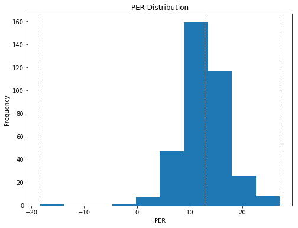

```python
from matplotlib.pyplot import figure

figure(figsize = (8,6))
PER_dist = plt.hist(dep_var)
plt.xlabel('PER')
plt.ylabel('Frequency')
plt.title('PER Distribution')
plt.axvline(np.mean(dep_var), color='k', linestyle='dashed', linewidth=1) #plot mean on histogram
plt.axvline(np.min(dep_var), color='k', linestyle='dashed', linewidth=1)  #plot min on histogram
plt.axvline(np.max(dep_var), color='k', linestyle='dashed', linewidth=1)  #plot max on histogram
plt.show()
```

The data seems about normally distributed, which is ideal to work with. There seems to be a few data points that are skewing the distribution to the left. I will invistagate these points further and most likely will end up removing them, hopefully this will also reduce the variance, which will help prediction errors.

```python
nba_df.loc[nba_df['PER'] < 0] # check points below 0
```

|  | Name | G | GS | MP | FG | FGA | FG% | 3P | 3PA | 3P% | ... | DRB | TRB | AST | STL | BLK | TOV | PF | PTS | WS | PER |
| --- | --- | --- | --- | --- | --- | --- | --- | --- | --- | --- | --- | --- | --- | --- | --- | --- | --- | --- | --- | --- | --- |
| 167 | Darius Johnson-Odom | 7.0 | 0.0 | 3.0 | 0.0 | 1.6 | 0.000 | 0.0 | 0.6 | 0.00 | ... | 0.7 | 0.9 | 0.3 | 0.1 | 0.0 | 0.3 | 0.4 | 0.0 | -0.3 | -18.4 |
| 247 | Andy Rautins | 5.0 | 0.0 | 4.8 | 0.6 | 1.4 | 0.429 | 0.2 | 0.8 | 0.25 | ... | 0.2 | 0.2 | 0.6 | 0.2 | 0.0 | 1.4 | 0.0 | 1.6 | -0.2 | -1.2 |

2 rows × 28 columns

Taking these players will be beneficial to the model as they are outliers (less than 10 games played with heavily negativly skewed PER). In the next cell I will remove these players from both dataframes and our dependent variable.

```python
nba_df = nba_df.drop(['167','247'], axis = 'index')
col_df = col_df.drop(['167','247'], axis = 'index')
dep_var = dep_var.drop(['167','247'], axis = 'index')
```

## Examine relationships with independent variables (college stats)

```
Text(0.5,1,'Correlation Heatmap')
```

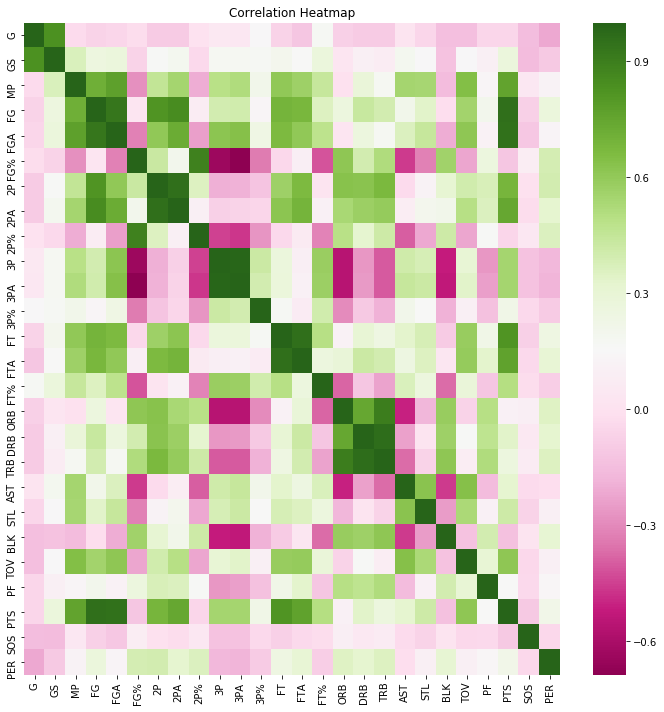

```python
import seaborn as sns   #data visualizations

df = col_df.join(dep_var)  #dataframe of all variables
figure(figsize = (12,12))
ax = plt.axes()
corr = df.corr()
sns.heatmap(corr, xticklabels=corr.columns.values,yticklabels=corr.columns.values, cmap = 'PiYG')
ax.set_title('Correlation Heatmap')
```

It looks like there is some instances of high auto correlation, so I may remove some independent variables that seem redundent. Unfortunatly, there does not seem to be a very high correlation with PER and any of the independent variables. This means I, may, need to examine non-linear relationships, multivariate relationships, or the possibility that using college basketball stats to predict players future PER is not a good experiment. My first step will be to drop columns of the df dataframe that I determine as uncessary. I will drop the shots made of every stat (2P, 3P, FT, FG) as I feel the combo of attempts and percentage success accuratly captures these statistics. I think it may also be wise to drop G, GS, MP as these are not used to calculate PER and a player who plays a lot of minutes does not mean they are efficent. Lastly, I will drop defensive rebounds as it is captured in total rebounds and offensive rebounds. All of this will make the relationships easier to identify.

## Reduce dimensionality

```python
cols_drop = ['2P', '3P', 'FT', 'FG', 'G', 'GS','MP', 'DRB']
df = df.drop(columns = cols_drop)
```

```python
df.head(n=10)  #dataframe with dropped columns
```

|  | Name | FGA | FG% | 2PA | 2P% | 3PA | 3P% | FTA | FT% | ORB | TRB | AST | STL | BLK | TOV | PF | PTS | SOS | PER |
| --- | --- | --- | --- | --- | --- | --- | --- | --- | --- | --- | --- | --- | --- | --- | --- | --- | --- | --- | --- |
| 0 | Karl-Anthony Towns | 6.6 | 0.566 | 6.4 | 0.577 | 0.2 | 0.250 | 3.4 | 0.813 | 2.4 | 6.7 | 1.1 | 0.5 | 2.3 | 1.4 | 2.9 | 10.3 | 8.67 | 24.5 |
| 1 | D'Angelo Russell | 14.7 | 0.449 | 8.1 | 0.479 | 6.6 | 0.411 | 4.5 | 0.756 | 1.0 | 5.7 | 5.0 | 1.6 | 0.3 | 2.9 | 2.1 | 19.3 | 7.37 | 14.4 |
| 2 | Jahlil Okafor | 11.1 | 0.664 | 11.1 | 0.664 | 0.0 | 0.000 | 5.1 | 0.510 | 3.5 | 8.5 | 1.3 | 0.8 | 1.4 | 2.5 | 2.1 | 17.3 | 9.87 | 16.0 |
| 3 | Willie Cauley-Stein | 5.6 | 0.593 | 5.6 | 0.593 | 0.0 | 0.000 | 2.8 | 0.508 | 2.4 | 6.2 | 0.9 | 1.1 | 2.2 | 1.2 | 2.3 | 8.0 | 8.12 | 16.5 |
| 4 | Stanley Johnson | 10.3 | 0.446 | 7.2 | 0.478 | 3.1 | 0.371 | 4.7 | 0.742 | 2.0 | 6.5 | 1.7 | 1.5 | 0.4 | 2.2 | 2.6 | 13.8 | 7.41 | 8.4 |
| 5 | Frank Kaminsky | 7.0 | 0.522 | 5.1 | 0.580 | 1.9 | 0.369 | 2.7 | 0.763 | 1.3 | 4.6 | 1.3 | 0.5 | 1.1 | 0.8 | 1.6 | 10.1 | 9.61 | 13.3 |
| 6 | Justise Winslow | 9.1 | 0.486 | 6.3 | 0.516 | 2.8 | 0.418 | 4.0 | 0.641 | 1.3 | 6.5 | 2.1 | 1.3 | 0.9 | 1.8 | 2.8 | 12.6 | 9.87 | 9.5 |
| 7 | Myles Turner | 7.6 | 0.455 | 5.7 | 0.513 | 1.8 | 0.274 | 3.3 | 0.839 | 1.3 | 6.5 | 0.6 | 0.3 | 2.6 | 1.4 | 2.4 | 10.1 | 9.07 | 17.2 |
| 8 | Trey Lyles | 6.7 | 0.488 | 5.9 | 0.536 | 0.8 | 0.138 | 2.8 | 0.735 | 1.8 | 5.2 | 1.1 | 0.5 | 0.4 | 1.1 | 1.6 | 8.7 | 8.67 | 13.3 |
| 9 | Devin Booker | 7.0 | 0.496 | 6.4 | 0.518 | 0.6 | 0.275 | 2.9 | 0.658 | 2.1 | 5.7 | 0.8 | 0.6 | 0.6 | 1.6 | 2.3 | 9.0 | 5.58 | 14.7 |

I would like to view a correlation chart with the reduced features.

```
Text(0.5,1,'Reduced Correlation Heatmap')
```

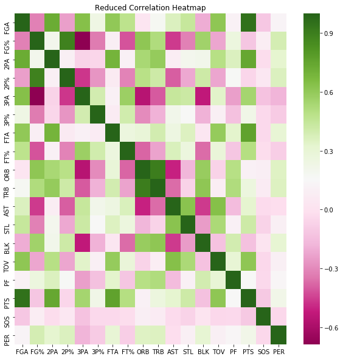

```python
figure(figsize = (10,10))
ax = plt.axes()
corr = df.corr()
sns.heatmap(corr, xticklabels=corr.columns.values,yticklabels=corr.columns.values, cmap = 'PiYG')
ax.set_title('Reduced Correlation Heatmap')
```

[figure not shown]

```python
def vars_plot (x_var, y_var):  #function to create a scatter plot for each x variable
    scat_plt = plt.scatter(df[x_var], df[y_var])
    plt.xlabel(x_var)
    plt.ylabel(y_var)
    plt.title(y_var + ' Vs. ' + x_var)
    return scat_plt

fig, ax = plt.subplots(3, 6, figsize = (12,12))
x_cord = 0
y_cord = 0

for var in list(df)[1:18]:
    #plot = vars_plot(var, 'PER')
    ax[x_cord, y_cord].scatter(df[var], df['PER'])
    ax.set_title()
    y_cord += 1
    if y_cord > 5:
        x_cord += 1
        y_cord = 0
```

## Try some introductory models

The first step is to spit the data into train and test components and define a function to measure the results. I will use a simple error function defined as sqrt((predicted - actual)^2), known as root mean squared error.

```python
from sklearn.model_selection import train_test_split  # library used for model building

def calc_rmse(predicted, actual):
    #mse = (predicted - actual) ** 2
    #rmse = np.sqrt(mse)
    #return rmse
x_vars = ['FGA', 'FG%', '2PA', '2P%', '3PA', '3P%', 'FTA', 'FT%', 'ORB', 'TRB', 'AST', 'STL', 'BLK', 'TOV', 'PF', 'PTS', 'SOS', 'PER']
x_vars = df[x_vars]
ind_vars = x_vars
ind_train, ind_test, dep_train, dep_test = train_test_split(ind_vars, dep_var, train_size = .80)
```

[output not shown]